## Data

Presented are two major data tables in the orchard scaling project (2012-2013) conducted at Kaysville Research Farm, USU. Five 24 year old tart cherry (*Prunus cerasus* Montmorency, *P. mahaleb*) from one block and 19 8 year-old apples (*Malus domestica* “Golden Delicious”) from one block with various rootstocks were sampled. BranchSegments.csv (*branch_size*) contains the size and orientation data for all trees sampled at a branch-level. TreeSummary.csv (*tree_sum*) contains the size and orientation data for all trees sampled at a tree-level. Listing of fields represented in the data are located at the end of this dococument for both data files. Data is analysed using Standardized Major Axis (SMA; aka reduced major axis) with R-package ‘smatr’

## Results

### Mass vs. Diameter [Predicted: M ~ D^8/3; Niklas & Spatz, 2004]

#### Tree Level [Estimated: 2.49 +/- 0.18, R2 = 0.974]

[figure not shown]

I would consider this spot on!!! It’s just a little shy of the 8/3 buckling, which is within the statistical limits.

#### Branch Level [Estimated 2.48 +/- 0.05, R2 = 0.905]

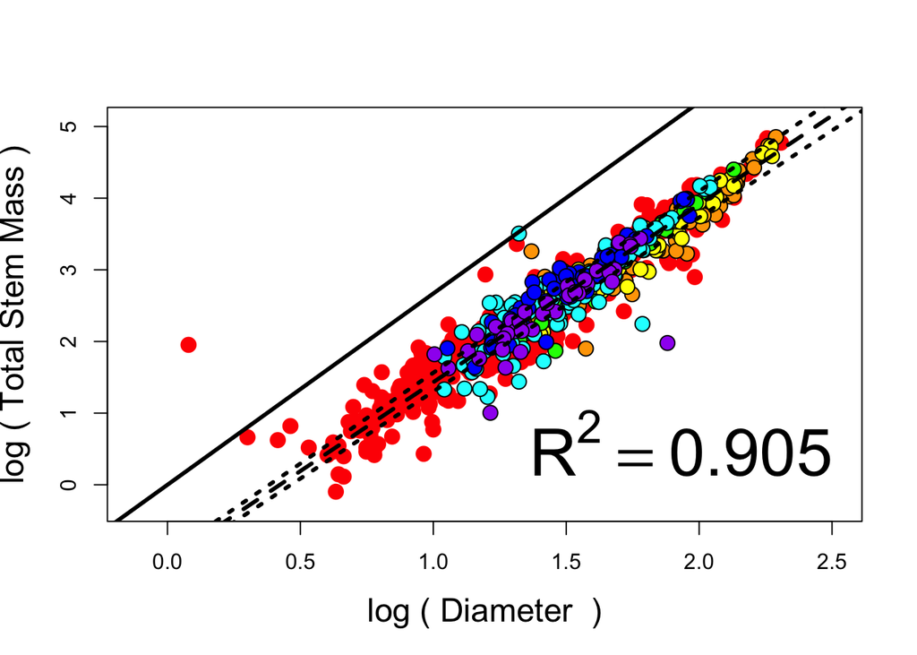

Again, this is just shallaw of the prediction, and begins to show a signal of pruning (i.e., mass removal)!

### Length vs. Diameter [Predicted: L ~ (D/2)^2/3; Price, Enquist & Savage, 2007]

#### Tree Level [Estimated: 0.74 +/- 0.12, R2 = 0.849]

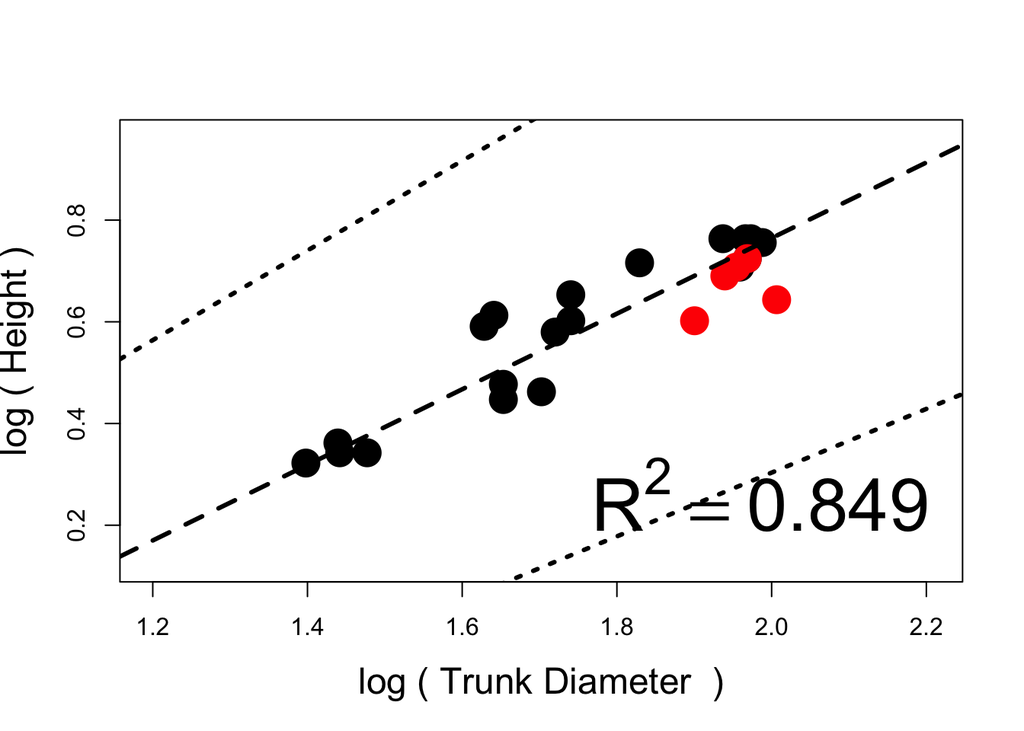

The statistical result again includes the 2/3 expectation, but suggests closer to a 3/4. I don’t have an explanation just yet.

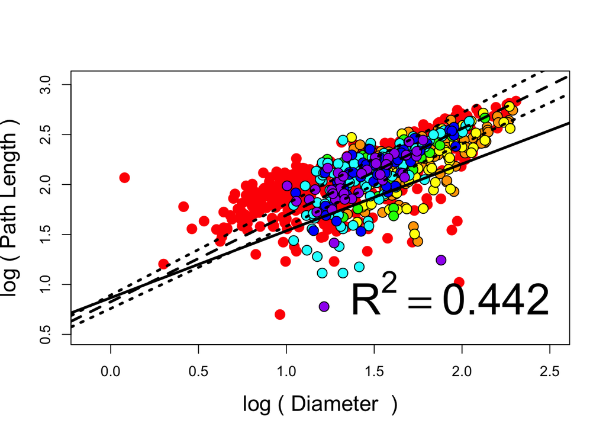

This is even more beyond the 2/3 expectaiton, with more length per diameter. Might be an artifact of vigorous shoots or a deviation in methods where I measured diameter at the midpoint instead of at the node.